# Week 1 - R solutions

Snorre Jallbjørn

Autumn, 2021

# Exercise 1

### Question 1.2

Inspect `HMDobj` by calling `str`.

```r
str(HMDobj)
```

```
## Classes 'HMDdatClass', 'R6' <HMDdatClass>
##   Public:
##     clone: function (deep = FALSE)
##     data: active binding
##     getOEdata: function (groups = NULL, agelim = NULL, timelim = NULL)
##     getSmoothMu: function (groups = NULL, agelim = NULL, timelim = NULL)
##     initialize: function (Otxtfile, Etxtfile, groups = c("Female", "Male"))
##     print: function (...)
##   Private:
##     .data: list
##     .verifyAgelim: function (agelim)
##     .verifyGroupName: function (groups)
##     .verifyTimelim: function (timelim)
```

Try to overwrite `HMDobj$data` or anything within it.

```r
HMDobj$data <- 5
```

```
## Error: data is read-only.
```

### Question 1.3

Extract some data using `HMDobj$getOEdata` and `HMDobj$getSmoothMu`.

```r
HMDobj$getOEdata(groups = "f")
```

```
## Error in private$.verifyGroupName(groups): Argument 'groups' must be one (or more) of the following:
##     Female, Male
```

```r
HMDobj$getOEdata(agelim = c(0, 120))
```

```
## Error in private$.verifyAgelim(agelim): Ages must be in the interval 0 to 110
```

```r
str(HMDobj$getOEdata(timelim = c(1950, 2020)))
```

```
## List of 5
##  $ groups : chr [1:2] "Female" "Male"
##  $ agelim : int [1:2] 0 110
##  $ timelim: num [1:2] 1950 2020
##  $ O      : num [1:2, 1:111, 1:71] 1003 1442 84 115 52 ...
##   ..- attr(*, "dimnames")=List of 3
##   .. ..$ Group: chr [1:2] "Female" "Male"
##   .. ..$ Age  : chr [1:111] "0" "1" "2" "3" ...
##   .. ..$ Year : chr [1:71] "1950" "1951" "1952" "1953" ...
##  $ E      : num [1:2, 1:111, 1:71] 38297 39959 38631 40566 41290 ...
##   ..- attr(*, "dimnames")=List of 3
##   .. ..$ Group: chr [1:2] "Female" "Male"
##   .. ..$ Age  : chr [1:111] "0" "1" "2" "3" ...
##   .. ..$ Year : chr [1:71] "1950" "1951" "1952" "1953" ...
##  - attr(*, "class")= chr "OEdata"
```

### Question 1.4

Write a function that takes an `OEdata`-class as input and returns an object of class `surf` containing the group names, an agelim, a timelim, and the empiric mortality surface (O/E-rates).

```r
OEdata <- HMDobj$getOEdata()
calc.rawOE <- function(OEdata) {
    # Verify that the input is of class OEdata. Stop if not.
    if(class(OEdata)!="OEdata") stop("Input should be of class 'OEdata'")

    # Calculate OE-rates for all ages and years within input object
    mu <- OEdata$O/OEdata$E
    mu[OEdata$E == 0] <- 0

    # Output an object of class 'surf'
    structure(list(groups  = OEdata$group,
                   agelim  = OEdata$agelim,
                   timelim = OEdata$timelim,
                   mu      = mu),
              class = 'surf')
}
rawOEsurf <- calc.rawOE(OEdata)
str(rawOEsurf) # Compare to str(HMDobj$getSmoothMu("Female"))
```

```
## List of 4
##  $ groups : chr [1:2] "Female" "Male"
##  $ agelim : int [1:2] 0 110
##  $ timelim: int [1:2] 1835 2020
##  $ mu     : num [1:2, 1:111, 1:186] 0.1863 0.2368 0.0561 0.0613 0.0412 ...
##   ..- attr(*, "dimnames")=List of 3
##   .. ..$ Group: chr [1:2] "Female" "Male"
##   .. ..$ Age  : chr [1:111] "0" "1" "2" "3" ...
##   .. ..$ Year : chr [1:186] "1835" "1836" "1837" "1838" ...
##  - attr(*, "class")= chr "surf"
```

### Question 1.5

Write a function `surf2plotdat` that takes a `surf`-object as input and returns a data frame based on `surf$mu` but transformed from wide to long format with columns `Group`, `Age`, `Year`, and `Mu`.

```r
# Custom
surf2plotdat <- function(surf) {
    ng <- length(surf$groups)
    na <- lim2length(surf$agelim)
    ny <- lim2length(surf$timelim)
    data.frame( Group = rep(surf$groups          , times = na*ny)
              , Age   = rep(lim2vec(surf$agelim) , times = ng, each = ny)
              , Year  = rep(lim2vec(surf$timelim), each  = ng*na)
              , Mu    = as.vector(surf$mu)
    )
}

# Melt
surf2plotdat <- function(surf) {
    reshape2::melt(surf$mu, varnames = c("Group", "Age", "Year"), value.name = "Mu")
}
```

### Question 1.6

Plot the O/E-rates for Danish females and males, ages 0–110 in the year 2020 on a suitable scale. Superimpose the smoothed rates.

```r
library("ggplot2")
library("scales")
theme_set(theme_bw())

plotdat_raw <- surf2plotdat(rawOEsurf)
plotdat_smo <- surf2plotdat(HMDobj$getSmoothMu())
str(plotdat_raw)
```

```
## 'data.frame':    41292 obs. of  4 variables:
##  $ Group: Factor w/ 2 levels "Female","Male": 1 2 1 2 1 2 1 2 1 2 ...
##  $ Age  : int  0 0 1 1 2 2 3 3 4 4 ...
##  $ Year : int  1835 1835 1835 1835 1835 1835 1835 1835 1835 1835 ...
##  $ Mu   : num  0.1863 0.2368 0.0561 0.0613 0.0412 ...
```

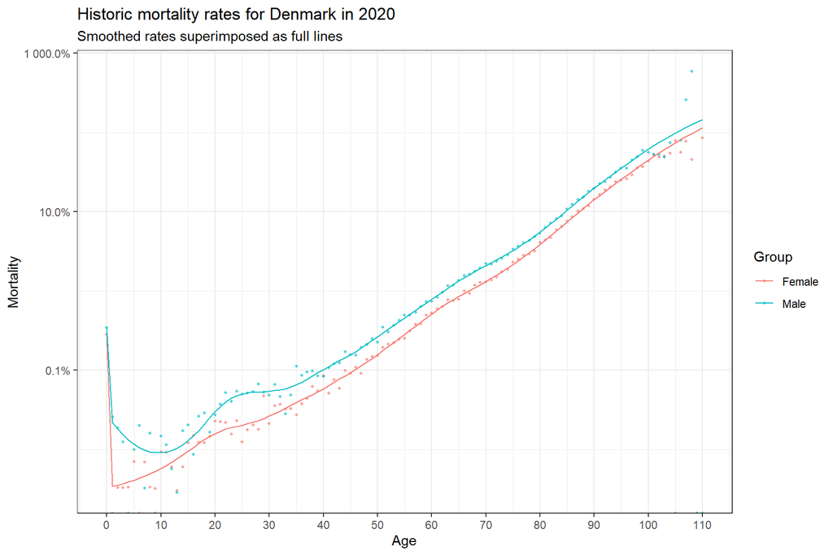

```r
subdat_raw <- plotdat_raw[plotdat_raw$Year==2020,]
subdat_smo <- plotdat_smo[plotdat_smo$Year==2020,]

ggplot(mapping = aes(x = Age, y = Mu, color = Group)) +
    geom_point(data = subdat_raw, alpha = 0.6, size = .8) +
    geom_line(data = subdat_smo) +
    scale_x_continuous(breaks = seq(from = 0, to = 110, by = 10)) +
    scale_y_continuous(trans = log10_trans(), labels = percent_format(accuracy = 0.1)) +
    labs(title    = "Historic mortality rates for Denmark in 2020",
         subtitle = "Smoothed rates superimposed as full lines",
         y        = "Mortality")
```

### Question 1.7

Plot the smoothed O/E-rates for Danish females and males, ages $0, 10, \dots, 100$ over the years 1950–2020 on a suitable scale.

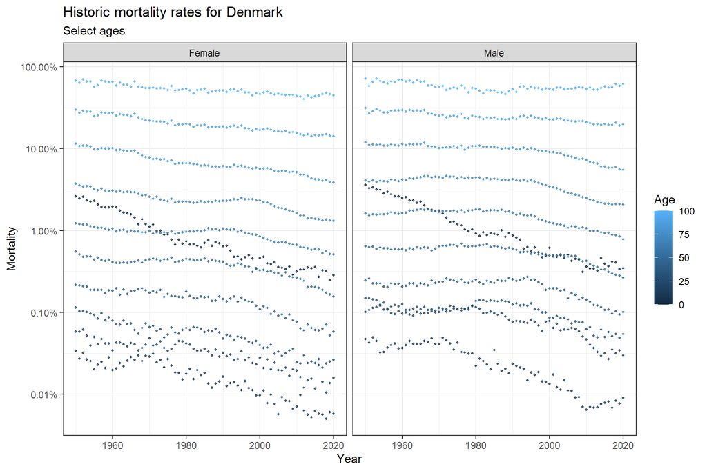

```r
aidx   <- seq(0, 100, by = 10)
subdat <- subset(plotdat_smo, Age %in% aidx & Year %in% 1950:2020)
ggplot(subdat, aes(x = Year, y = Mu, color = Age)) +
    geom_point(alpha = .8, size = .8) +
    scale_y_continuous(trans = log10_trans(), labels = percent_format(accuracy = 0.01)) +
    labs(title    = "Historic mortality rates for Denmark",
         subtitle = "Select ages",
         y        = "Mortality") +
    facet_grid(~Group)
```

# Exercise 2

### Question 2.2 and 2.3

Let $\mu(x) = \alpha \exp(\beta x)$. Note that $I(x) = \int_0^x \mu(u) du = \frac{a}{b}(\exp(\beta x)-1)$ whereby $I^{-1}(x) = \frac{\log \left(\frac{b}{a}x+1 \right)}{b}$.

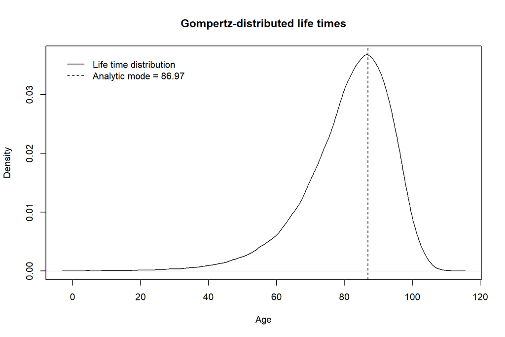

```r
E <- rexp(1e5) # Simulate from exp(1)
a <- exp(-11)  # Level
b <- 0.10      # Slope

# Simulation using relation from Q.2.1
Iinv <- function(x) {(log(b/a*x+1))/b}
lifetimes <- Iinv(E)
plot(density(lifetimes), xlab = "Age", ylab = "Density", main = "Gompertz-distributed life times")

# Add mode
M <- log(b/a)/b
abline(v=M,lty=2)
legend('topleft', legend = c("Life time distribution", paste0("Analytic mode = ", round(M,2)))
       , inset=.03, lty = c(1,2), bty = "n")
```

The Gompertz law can provide a good fit to most adult ages, but the curvature is wrong for the very young, and it overstates mortality for the oldest-old.

# Exercise 3

### Question 3.6

Write a function in R that computes the period life expectancy under the assumption of a piecewise constant hazard

```r
smooth.mu <- HMDobj$getSmoothMu()

calc.period.life <- function(surf, group, age, year) {
    # We could implement a bunch of checks here...
    if (class(surf)[1] != "surf")
      stop("Input 'surf' must be of class 'surf'.", call.=F)
    if (!any(group == surf$group))
      stop("Input 'group' must be one of the following: ", paste(surf$groups, collapse = ", "), call.=F)
    if (age  < surf$agelim[1]  | surf$agelim[2] < age)
      stop("Input 'age' must be in the range ", surf$age[1],"-",surf$age[2],".", call.=F)
    if (year < surf$timelim[1] | surf$timelim[2] < year)
      stop("Input 'year' must be in the range ", surf$timelim[1],"-",surf$timelim[2],".", call.=F)

    # Find indices
    gidx  <- group == surf$group
    aidx  <- lim2vec(surf$agelim) %in% (age:surf$agelim[2L])
    tidx  <- year == lim2vec(surf$timelim)

    # Extract mu-vector and calculate life exp.
    muvec <- surf$mu[gidx, aidx, tidx]
    Svec  <- c(1,exp(-cumsum(muvec[-length(muvec)])))
    sum((1-exp(-muvec))/muvec*Svec)
}

# Verify that life exp. for a Danish female at age 60 in 2015 is 24.84
calc.period.life(smooth.mu, "Female", 60, 2015)
```

```
## [1] 24.83625
```